# Analyse der erhobenen Daten

Raphael Balzer

2023-06-08

# Auswertung der Daten

## Datenimport und Laden der Pakete

```r
library(readxl)
library(sjmisc)
library(tidyverse)
```

```r
library(ggstatsplot)
library(rstanarm)
library(easystats)
daten <- read_excel("data_rpDV41_2023-06-10_13-48.xlsx")
View(daten)
```

## Vergleich der Mittelwerte der Interessenssteigerung

### Berechnung der Summen

Für den Vergleich müssen wir erst die Summen der Items berechnen und dann die Summen des Interesses vor Betrachtung des Stimulus von denen nach der Betrachtung des Stimulus subtrahieren.

```r
daten <-
daten %>%
  select(!c(SERIAL:STARTED, MAILSENT, LASTDATA, MISSING, MISSREL, MAXPAGE,
            R001_CP, TIME001:TIME004, TIME006:TIME011))
daten <- daten %>%
   row_sums(daten[21:24], n = 4, var = "sum_ibefore") %>%
   row_sums(daten[25:28], n = 4, var = "sum_iafter")

daten <- daten[complete.cases(daten[c("sum_ibefore", "sum_iafter")]), ]

daten <- daten %>%
  mutate(sum_diff = sum_iafter - sum_ibefore)
```

### Berechnung und Visualisierung der Mittelwerte

Nun können wir einfach die Mittelwerte der Differenzen bilden und visualisieren.

```r
daten <- daten %>%
  group_by(R001) %>%
  mutate(mean_diff = mean(sum_diff))

ggbetweenstats(
  daten,
  x = R001,
  y = sum_diff,
  results.subtitle = FALSE
)
```

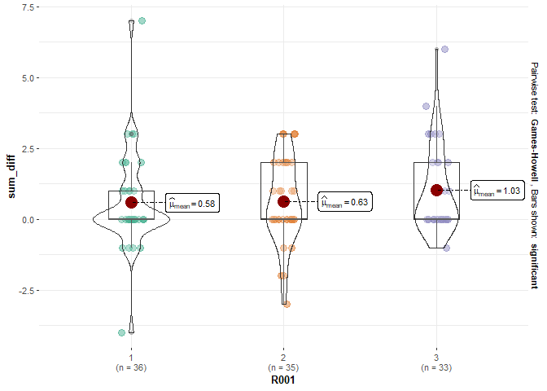

Jetzt sehen wir die Unterschiede in der Interessenssteigerung für jede Gruppe. Die Unterschiede fallen äußerst gering aus, nichtsdestotrotz ist ein leichter Unterschied zu erkennen, der sich mit unserer Hypothese deckt, nämlich fällt die Interessenssteigerung beim animierten Graph höher aus, als beim statischen und die Steigerung beim interaktiven wiederum höher als beim animierten. Bemerkenswert ist außerdem, dass es bei Gruppe 3 nur einen Fall gibt, bei dem sich eine Interessensminderung abzeichnet, während es bei den anderen beiden Gruppen sowohl mehr, als auch extremere Fälle dieser Art gibt.

## Berechnung des Modells

Nun berechnen wir das Modell, als die Interessenssteigerung in Abhängigkeit von der Versuchsgruppe:

```r
daten1 <- daten %>%
  mutate(R001 = factor(R001))

lm1 <- stan_glm(sum_diff ~ R001,
                data = daten1,
                refresh = 0)
```

## Prüfen auf Signifikanz

### Interpretation der Modellparameter

Nun sehen wir uns die Koeffizienten des Modells an:

```r
parameters(lm1)
```

| Parameter | Median | CI | CI_low | CI_high | pd | Rhat | ESS | Prior_Distribution | Prior_Location | Prior_Scale |
| --- | --- | --- | --- | --- | --- | --- | --- | --- | --- | --- |
| (Intercept) | 0.58640770 | 0.95 | 0.06686617 | 1.1162583 | 0.98550 | 1.000792 | 2994.571 | normal | 0.7403846 | 3.956609 |
| R0012 | 0.04502801 | 0.95 | -0.71614234 | 0.7596206 | 0.53950 | 1.000600 | 3585.388 | normal | 0.0000000 | 8.332971 |
| R0013 | 0.44701635 | 0.95 | -0.32392031 | 1.2157221 | 0.86675 | 1.000359 | 3387.988 | normal | 0.0000000 | 8.460038 |

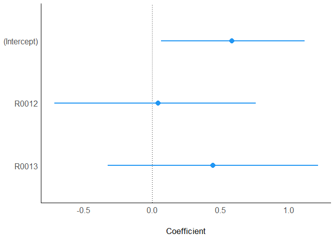

```r
parameters(lm1) %>% plot(show_intercept = TRUE)
```

### ROPE-Test

Testen der Hypothese mit dem ROPE-Verfahren:

```r
rope(lm1)
```

|  | Parameter | CI | ROPE_low | ROPE_high | ROPE_Percentage | Effects | Component |
| --- | --- | --- | --- | --- | --- | --- | --- |
| 1 | (Intercept) | 0.95 | -0.1582644 | 0.1582644 | 0.02631579 | fixed | conditional |
| 2 | R0012 | 0.95 | -0.1582644 | 0.1582644 | 0.33894737 | fixed | conditional |
| 3 | R0013 | 0.95 | -0.1582644 | 0.1582644 | 0.17052632 | fixed | conditional |

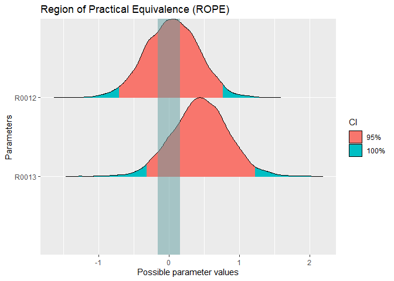

```r
rope(lm1) %>% plot()
```

```r
report(lm1)
```

```
## We fitted a Bayesian linear model (estimated using MCMC sampling with 4 chains
## of 2000 iterations and a warmup of 1000) to predict sum_diff with R001
## (formula: sum_diff ~ R001). Priors over parameters were all set as normal (mean
## = 0.00, SD = 8.33; mean = 0.00, SD = 8.46) distributions. The model's
## explanatory power is weak (R2 = 0.03, 95% CI [3.72e-06, 0.09], adj. R2 =
## -0.03). The model's intercept, corresponding to R001 = 1, is at 0.59 (95% CI
## [0.07, 1.12]). Within this model:
##
##   - The effect of R001 [2] (Median = 0.05, 95% CI [-0.72, 0.76]) has a 53.95%
## probability of being positive (> 0), 46.58% of being significant (> 0.08), and
## 12.00% of being large (> 0.47). The estimation successfully converged (Rhat =
## 1.001) and the indices are reliable (ESS = 3585)
##   - The effect of R001 [3] (Median = 0.45, 95% CI [-0.32, 1.22]) has a 86.67%
## probability of being positive (> 0), 82.12% of being significant (> 0.08), and
## 46.90% of being large (> 0.47). The estimation successfully converged (Rhat =
## 1.000) and the indices are reliable (ESS = 3388)
##
## Following the Sequential Effect eXistence and sIgnificance Testing (SEXIT)
## framework, we report the median of the posterior distribution and its 95% CI
## (Highest Density Interval), along the probability of direction (pd), the
## probability of significance and the probability of being large. The thresholds
## beyond which the effect is considered as significant (i.e., non-negligible) and
## large are |0.08| and |0.47|. Convergence and stability of the Bayesian sampling
## has been assessed using R-hat, which should be below 1.01 (Vehtari et al.,
## 2019), and Effective Sample Size (ESS), which should be greater than 1000
## (Burkner, 2017).
```

# Fazit

Für den Effekt des Diagrammtyps ist keine klare inferenzstatistische Aussage hinsichtlich eines Indifferenzbereichs möglich: Es ist plauibel, laut dem Modell, dass es einen praktisch bedeutsamen Unterschied gibt, aber es ist auch plausibel, dass es keinen praktisch bedeutsamen Unterschied gibt.